# Twitter stock market sentiment analysis

Sushant Khot

# Introduction

I am excited to present a project on Twitter Stock Market Sentiment Analysis for 3 Stocks that were Top Gainers and 3 Stocks that were Top Losers on Oct 14th, 2020. I have referred https://finance.yahoo.com/ to identify the top Day Gainers and Losers. The idea behind the project is to identify these Top Gainer and Loser stocks on a particular day and extract the tweets using Twitter API via R. We will be doing the Twitter Social Media Sentiment Analysis of these Stocks and to extract them from Twitter, we will be using the cashtags. The cashtags easily identify the Stock symbols for these companies and the tweets / data that we will search for will be more relevant to stock market sentiments on these Gainers and Losers of the Day.

We have considered the Most Active Stock symbols in United States on the given day Oct 14th, 2020.

The filters we have applied to get the below Most Active in United States Market - Top Gainers and Top Losers of the Day are as follows:

1. Region = United States
2. Market Cap (Intraday) = Mega Cap
3. Volume (Intraday) greater than 5000000

**Stock Filter**

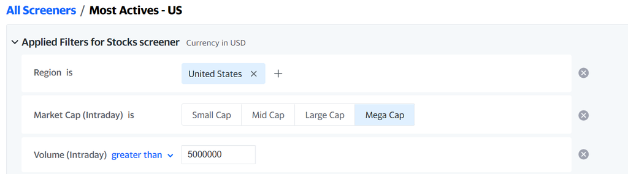

**Top Gainers of the Day**

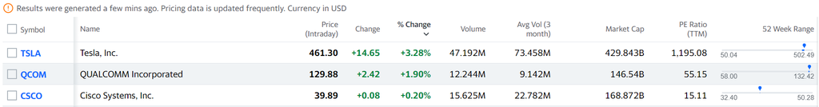

**Top Losers of the Day**

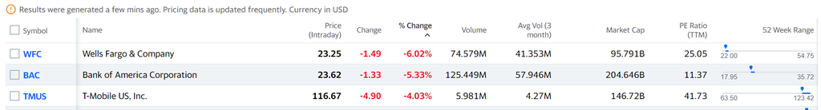

Based on the above filter we get the below Top Gainers and Top Losers of the Day.

- **Tesla, Inc. - TSLA** - We will use **$TSLA** for our Tweet search.
- **QUALCOMM Incorporated - QCOM** - We will use **$QCOM** for our Tweet search.
- **Cisco Systems, Inc. - CSCO** - We will use **$CSCO** for our Tweet search.

- **Wells Fargo & Company - WFC** - We will use **$WFC** for our Tweet search.
- **Bank of America Corporation - BAC** - We will use **$BAC** for our Tweet search.
- **T-Mobile US, Inc. - TMUS** - We will use **$TMUS** for our Tweet search.

# Part A

## Extracting Tweets

**R Libraries used for Analysis**

The R Libraries used for analysis are `rtweet`, `dplyr`, `tidyr`, `ggplot2`, `tidytext`, `tidyverse`, `SnowballC`, `gridExtra` and `wordcloud`.

```r
library(rtweet)
library(dplyr)
library(tidyr)
library(tidytext)
library(tidyverse)
library(SnowballC)
library(ggplot2)
library(gridExtra) # Side by Side ggplot
library(wordcloud)
```

I have stored my Twitter Authentication Tokens and Keys in a file “twitterAuthentication.Rdata”. I load the “twitterAuthentication.Rdata” to Authenticate me without having me to login in Twitter from the Browser.

```r
# save(app_name, consumer_key,consumer_secret,access_token,access_secret, file = 'C:/Users/sushk/Downloads/BU/MET CS 688/Term Project/twitterAuthentication.Rdata')

load("C:/Users/sushk/Downloads/BU/MET CS 688/Term Project/twitterAuthentication.Rdata")
```

The “twitterAuthentication.Rdata” file has the R objects needed to create a token listed as follows: app_name, consumer_key, consumer_secret, access_token and access_secret.

We will now create a token for Twitter Authentication and store in “token”.

```r
token <- create_token(app = app_name,
             consumer_key = consumer_key,
             consumer_secret = consumer_secret,
             access_token = access_token,
             access_secret = access_secret)
```

We will now extract the tweets using the cashtag searches with Twitter API via R

**Top Gainers for the Day**

We then search tweets for Top Gainer Stock “$TSLA”, “$QCOM” and “$CSCO” on Oct 14th, 2020 using the Twitter API in rtweet library - in that order

```r
# 1. Search Tweets for Top Gainer Stock "$TSLA" on Oct 14th, 2020 -----------
twt.topgainer.1 <- search_tweets("$TSLA", n = 100, include_rts = FALSE, lang = "en")

# Filter the tweets to get specific columns to Inspect
twt.topgainer.1 <- twt.topgainer.1 %>% select(screen_name,text,created_at)

# Inspect the tibble
glimpse(twt.topgainer.1)

# 2. Search Tweets for Top Gainer Stock "$QCOM" on Oct 14th, 2020 -----------
twt.topgainer.2 <- search_tweets("$QCOM", n = 100, include_rts = FALSE, lang = "en")

# Filter the tweets to get specific columns to Inspect
twt.topgainer.2 <- twt.topgainer.2 %>% select(screen_name,text,created_at)

# Inspect the tibble
glimpse(twt.topgainer.2)

# 3. Search Tweets for Top Gainer Stock "$CSCO" on Oct 14th, 2020 -----------
twt.topgainer.3 <- search_tweets("$CSCO", n = 100, include_rts = FALSE, lang = "en")

# Filter the tweets to get specific columns to Inspect
twt.topgainer.3 <- twt.topgainer.3 %>% select(screen_name,text,created_at)

# Inspect the tibble
glimpse(twt.topgainer.3)
```

**Top Losers for the Day**

Again for Top Loser Stocks, we use the Twitter API from rtweet library and search tweets having “$WFC”, “$BAC” and “$TMUS” on Oct 14th, 2020 - in that order

```r
# 1. Search Tweets for Top Loser Stock "$WFC" on Oct 14th, 2020 -----------
twt.toploser.1 <- search_tweets("$WFC", n = 100, include_rts = FALSE, lang = "en")

# Filter the tweets to get specific columns to Inspect
twt.toploser.1 <- twt.toploser.1 %>% select(screen_name,text,created_at)

# Inspect the tibble
glimpse(twt.toploser.1)

# 2. Search Tweets for Top Loser Stock "$BAC" on Oct 14th, 2020 -----------
twt.toploser.2 <- search_tweets("$BAC", n = 100, include_rts = FALSE, lang = "en")

# Filter the tweets to get specific columns to Inspect
twt.toploser.2 <- twt.toploser.2 %>% select(screen_name,text,created_at)

# Inspect the tibble
glimpse(twt.toploser.2)

# 3. Search Tweets for Top Loser Stock "$TMUS" on Oct 14th, 2020 -----------
twt.toploser.3 <- search_tweets("$TMUS", n = 100, include_rts = FALSE, lang = "en")

# Filter the tweets to get secific columns to Inspect
twt.toploser.3 <- twt.toploser.3 %>% select(screen_name,text,created_at)

# Inspect the tibble
glimpse(twt.toploser.3)
```

I have stored these Top Gainers and Top Loser Tweet objects in the “TweetsFile” file. We can load this directly to see the data I was able to extract to understand the analysis done on these specific tweets.

```r
# save(twt.topgainer.1, twt.topgainer.2, twt.topgainer.3, twt.toploser.1, twt.toploser.2, twt.toploser.3, file = "C:/Users/sushk/Downloads/BU/MET CS 688/Term Project/TweetsFile")

load("C:/Users/sushk/Downloads/BU/MET CS 688/Term Project/TweetsFile")
```

**Glimpse of Top Gainers:**

$TSLA:

```r
# Top Gainers of the Day
# TSLA
glimpse(twt.topgainer.1)
```

```
## Rows: 100
## Columns: 3
## $ screen_name <chr> "vcdxnz001", "GBella2020", "GBella2020", "GBella2020", ...
## $ text        <chr> "I just found out we have a Staff Engineer working @Tes...
## $ created_at  <dttm> 2020-10-14 22:58:52, 2020-10-14 22:58:47, 2020-10-14 2...
```

$QCOM:

```r
# QCOM
glimpse(twt.topgainer.2)
```

```
## Rows: 100
## Columns: 3
## $ screen_name <chr> "StckPro", "ErinCra36945952", "JhonTrade", "JhonTrade",...
## $ text        <chr> "$QCOM NEW ARTICLE : 5G Devices Will Spur Network Capac...
## $ created_at  <dttm> 2020-10-14 22:57:06, 2020-10-14 22:57:00, 2020-10-14 2...
```

$CSCO:

```r
# CSCO
glimpse(twt.topgainer.3)
```

```
## Rows: 100
## Columns: 3
## $ screen_name <chr> "ShellyG62375029", "ShellyG62375029", "ShellyG62375029"...
## $ text        <chr> "Free alerts, Option Sweeps , Trading Ideas \nfrom 3k t...
## $ created_at  <dttm> 2020-10-14 22:58:00, 2020-10-14 15:05:00, 2020-10-14 2...
```

**Glimpse of Top Losers:**

$WFC:

```r
# Top Losers of the Day
# WFC
glimpse(twt.toploser.1)
```

```
## Rows: 100
## Columns: 3
## $ screen_name <chr> "StckPro", "StckPro", "ErinCra36945952", "ErinCra369459...
## $ text        <chr> "$WFC NEW ARTICLE : Wells Fargo CFO Says Consumer Spend...
## $ created_at  <dttm> 2020-10-14 22:57:02, 2020-10-14 22:49:02, 2020-10-14 2...
```

$BAC:

```r
# BAC
glimpse(twt.toploser.2)
```

```
## Rows: 100
## Columns: 3
## $ screen_name <chr> "MC_OptionTrades", "IliketotweettoU", "IliketotweettoU"...
## $ text        <chr> "$BAC Makes an Outsized Move -5.3%. The 16-Oct-20 Optio...
## $ created_at  <dttm> 2020-10-14 22:57:56, 2020-10-14 22:57:25, 2020-10-14 2...
```

$TMUS:

```r
# TMUS
glimpse(twt.toploser.3)
```

```
## Rows: 95
## Columns: 3
## $ screen_name <chr> "ConvexValue", "MonitorAction", "JhonTrade", "JhonTrade...
## $ text        <chr> "Added Premium and Volume filters - this is a ranking o...
## $ created_at  <dttm> 2020-10-14 22:24:50, 2020-10-14 22:10:22, 2020-10-14 2...
```

## Combining Data

We will now combine each of the Gainers together in one data Frame and call it “twt.gainers”. We will do the same for Loser Stocks and call it “twt.losers”.

Additionally, I am also adding a “Name” Column to the data frames in order to identify the tweets by the company names

```r
twt.topgainer.1$Name <- "Tesla"
twt.topgainer.2$Name <- "QUALCOMM"
twt.topgainer.3$Name <- "Cisco"

twt.toploser.1$Name <- "Wells Fargo"
twt.toploser.2$Name <- "BOA"
twt.toploser.3$Name <- "TMobile"

twt.gainers <- rbind(twt.topgainer.1, twt.topgainer.2, twt.topgainer.3)

twt.losers <- rbind(twt.toploser.1, twt.toploser.2, twt.toploser.3)
```

**Check the combined data frames:**

Gainers:

```r
head(twt.gainers)
```

```
## # A tibble: 6 x 4
##   screen_name text                                     created_at          Name
##   <chr>       <chr>                                    <dttm>              <chr>
## 1 vcdxnz001   I just found out we have a Staff Engine~ 2020-10-14 22:58:52 Tesla
## 2 GBella2020  thanks!! $tsla  ethereum bitcoin $btc $~ 2020-10-14 22:58:47 Tesla
## 3 GBella2020  thanks!! $tsla  ethereum bitcoin $btc $~ 2020-10-14 22:43:52 Tesla
## 4 GBella2020  thanks!! $tsla  ethereum bitcoin $btc $~ 2020-10-14 22:57:40 Tesla
## 5 GBella2020  thanks!! $tsla  ethereum bitcoin $btc $~ 2020-10-14 22:39:20 Tesla
## 6 GBella2020  thanks!! $tsla  ethereum bitcoin $btc $~ 2020-10-14 22:55:23 Tesla
```

Losers:

```r
head(twt.losers)
```

```
## # A tibble: 6 x 4
##   screen_name   text                                 created_at          Name
##   <chr>         <chr>                                <dttm>              <chr>
## 1 StckPro       "$WFC NEW ARTICLE : Wells Fargo CFO~ 2020-10-14 22:57:02 Wells ~
## 2 StckPro       "$WFC NEW ARTICLE : Why Wells Fargo~ 2020-10-14 22:49:02 Wells ~
## 3 ErinCra36945~ "Best trading community on net.Join~ 2020-10-14 22:57:00 Wells ~
## 4 ErinCra36945~ "Best trading community on net.Join~ 2020-10-14 21:57:00 Wells ~
## 5 RAJURAYM      "Free entries &amp; exits given dai~ 2020-10-14 22:56:42 Wells ~
## 6 MarketFollows "Why Wells Fargo Got Slammed on Wed~ 2020-10-14 22:55:32 Wells ~
```

# Part B

## TidyText and Pre-processing

We will be using TidyText objects for Gainers and Losers stocks. As part if Pre-processing we will remove any http elements, emojis, other language contents and some othet HTML words manually.

We will then use unnest_tokens() function to convert the tweets to lowercase, remove punctuation, and add id for each tweet. Also we will remove any stopwords from the tweets and store it in a cleaned data frame. Note that we are not stemming the tweets.

```r
# Remove any http elements from the tweets.
 twt.gainers$stripped_text <- gsub("http\\S+", "", twt.gainers$text)

# Remove emojis AND other elements (other languages, etc.).
 twt.gainers$stripped_text <- gsub("[^\u0020-\u007F]+", "", twt.gainers$stripped_text)

 # I noticed &amp which was not getting removed by unnest_tokens, hence removing it manually.
 twt.gainers$stripped_text <- gsub("&amp+", "", twt.gainers$stripped_text)

# Now we do some preprocessing on the tweets using unnest_tokens() function to convert to lowercase, remove punctuation, and add id for each tweet

# Also we will remove any stopwords from the tweets and store it in a cleaned data frame.

 # Note that we are not stemming the tweets.

cleaned_twt.gainers <- twt.gainers %>%
  select(stripped_text) %>%
  unnest_tokens(word, stripped_text) %>%
  anti_join(stop_words)

# Now the same steps for Loser stock Tweets:
 twt.losers$stripped_text <- gsub("http\\S+", "", twt.losers$text)
 twt.losers$stripped_text <- gsub("[^\u0020-\u007F]+", "", twt.losers$stripped_text)
 twt.losers$stripped_text <- gsub("&amp+", "", twt.losers$stripped_text)

cleaned_twt.losers <- twt.losers %>%
  select(stripped_text) %>%
  unnest_tokens(word, stripped_text) %>%
  anti_join(stop_words)
```

**We can look at an example of Before and After per-processing a tweet for Gainers:**

Before Pre-processing:

```r
twt.gainers$text[50]
```

```
## [1] "$fb $dkng $nakd $idex $shll $cbat $boxl $xspa $ontx $vxrt $gevo $srne $novn $wwr $msft $sunw $lca $aal $nkla $nio $gme $opti $tsla $spaq $rkt $spy $wkhs $aapl $penn\n\nWE ALERTED $IBIO at $1.45 RAN TO $7 (370% GAIN!)\n\nDaily Alerts\n\nFREE TRIAL!\n\nBEAT THAT\n\n👇👇\n\n🚨LINK IN BIO🚨"
```

After Pre-processing:

```r
twt.gainers$stripped_text[50]
```

```
## [1] "$fb $dkng $nakd $idex $shll $cbat $boxl $xspa $ontx $vxrt $gevo $srne $novn $wwr $msft $sunw $lca $aal $nkla $nio $gme $opti $tsla $spaq $rkt $spy $wkhs $aapl $pennWE ALERTED $IBIO at $1.45 RAN TO $7 (370% GAIN!)Daily AlertsFREE TRIAL!BEAT THATLINK IN BIO"
```

**Also we can check this for a tweet for Loser stock:**

Before Pre-processing:

```r
twt.losers$text[50]
```

```
## [1] "Wall Street falls on dimmed stimulus hopes https://t.co/bfShNI9Rez @ReutersMoney @GerberKawasaki $JPM $BAC $WFC $AMC $UNH"
```

After Pre-processing:

```r
twt.losers$stripped_text[50]
```

```
## [1] "Wall Street falls on dimmed stimulus hopes  @ReutersMoney @GerberKawasaki $JPM $BAC $WFC $AMC $UNH"
```

We will now display the Cleaned data frame for Gainers and Losers having terms stored after pre-processing.

Clean Data Frame of Gainers Tweets terms:

```r
cleaned_twt.gainers
```

```
## # A tibble: 7,872 x 1
##    word
##    <chr>
##  1 found
##  2 staff
##  3 engineer
##  4 tesla
##  5 tsla
##  6 based
##  7 zealand
##  8 cool
##  9 global
## 10 company
## # ... with 7,862 more rows
```

Clean Data Frame of Losers Tweets terms:

```r
cleaned_twt.losers
```

```
## # A tibble: 6,736 x 1
##    word
##    <chr>
##  1 wfc
##  2 article
##  3 fargo
##  4 cfo
##  5 consumer
##  6 spending
##  7 picking
##  8 wfc
##  9 related
## 10 news
## # ... with 6,726 more rows
```

# Part C

## Frequent Terms

Now that we have done all the pre-processing and storing the clean terms in data frame, we will show and plot the most frequent terms used in Gainer Stock Tweets and Loser Stock Tweets.

**Frequent Terms in Gainers Stock tweets:**

```r
# Compute the most frequent terms for "Top Gainers" Tweets
freq.gainers <- cleaned_twt.gainers %>%
  count(word, sort = TRUE)
head(freq.gainers)
```

```
## # A tibble: 6 x 2
##   word      n
##   <chr> <int>
## 1 tsla    165
## 2 aapl    137
## 3 amd     123
## 4 qcom    121
## 5 spy     103
## 6 csco    102
```

Here we notice that the most frequent terms are basically the stock symbols as they arr listed most in the tweets.

**Frequent Terms in Losers Stock tweets**

```r
# Compute the most frequent terms for "Top Losers" Tweets
freq.losers <- cleaned_twt.losers %>%
  count(word, sort = TRUE)
head(freq.losers)
```

```
## # A tibble: 6 x 2
##   word      n
##   <chr> <int>
## 1 wfc     163
## 2 bac     146
## 3 aapl    109
## 4 tmus     94
## 5 tsla     87
## 6 nio      83
```

We see the same behavior here for Loser stock tweets and the most frequent terms are the stock symbols as they are listed most in the tweets.

**Plot of Frequent Terms:**

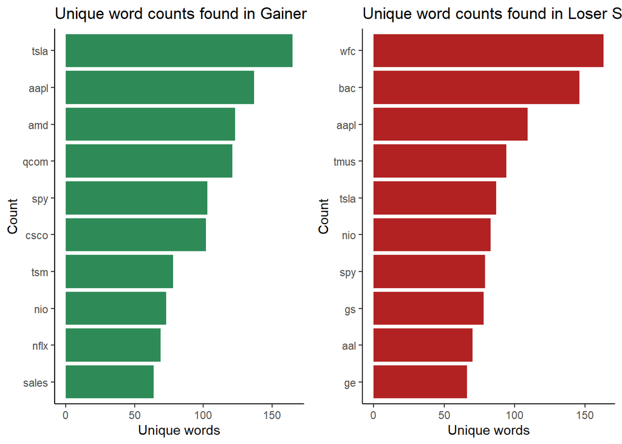

```r
# Plot the most frequent words for "Gainers" and "Losers" tweets:

plot.gainers <- cleaned_twt.gainers %>%
  count(word, sort = TRUE) %>%
  top_n(10) %>%
  mutate(word = reorder(word, n)) %>%
  ggplot(aes(x = word, y = n)) +
  geom_col(fill = "seagreen") +
  xlab(NULL) +
  coord_flip() +
  theme_classic() +
  labs(x = "Count",
       y = "Unique words",
       title = "Unique word counts found in Gainer stock tweets")

plot.losers <- cleaned_twt.losers %>%
  count(word, sort = TRUE) %>%
  top_n(10) %>%
  mutate(word = reorder(word, n)) %>%
  ggplot(aes(x = word, y = n)) +
  geom_col(fill = "firebrick") +
  xlab(NULL) +
  coord_flip() +
  theme_classic() +
  labs(x = "Count",
       y = "Unique words",
       title = "Unique word counts found in Loser Stock tweets")

# We will plot them side by side for comparison
grid.arrange(plot.gainers, plot.losers, ncol=2)
```

## Word Cloud

We are going to plot the top 100 terms in Gainers and Losers stock tweets. This should match with the top frequent words that we plotted above.

**Gainers Word Cloud:**

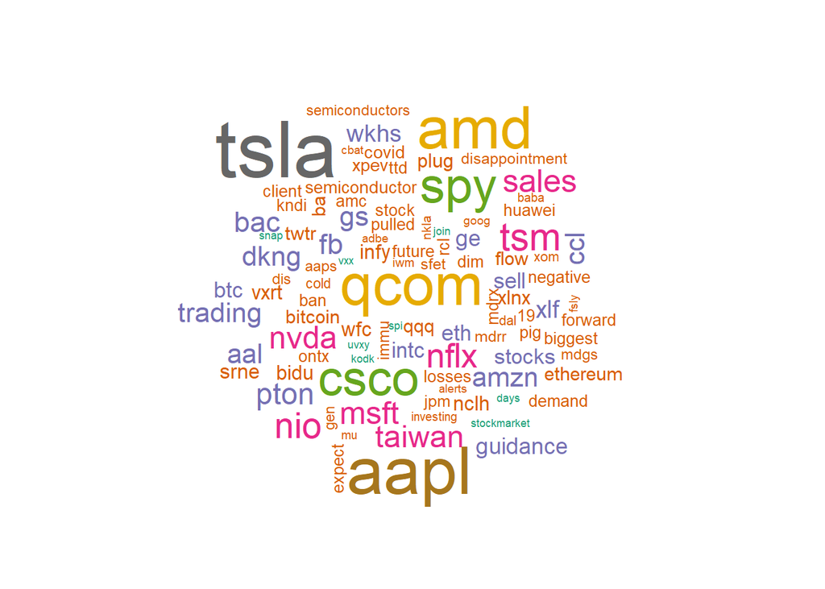

```r
# Word cloud for Gainers
wordcloud(freq.gainers$word[1:100], freq.gainers$n[1:100], colors=brewer.pal(8, "Dark2"), scale = c(4 , .1))
```

**Losers Word Cloud:**

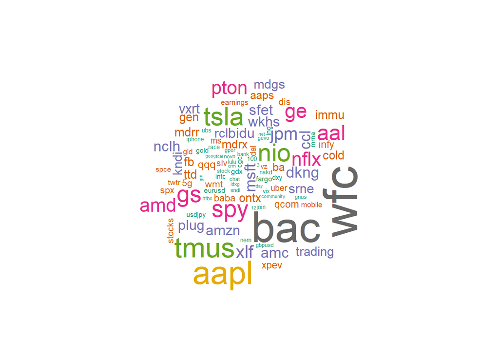

```r
# Word cloud for Losers
wordcloud(freq.losers$word[1:100], freq.losers$n[1:100], colors=brewer.pal(8, "Dark2"), scale = c(4 , .1))
```

# Part D

## Sentiment Analysis

Sentiment analysis is used for analyzing text and determining whether it conveys a positive, negative or a neutral sentiment. We will do the sentiment analysis of the Gainers and Losers Tweets based on the words used in the tweets. Additionally, We will compute the Sentiment Score for Gainers and Losers tweets. In the end we will try to judge if the gainers tweets are characterized by more positive words and do Losers stock tweets show more negative words or sentiments.

We will be using the “bing” lexicon from the tidytext package created by Bing Liu and collaborators. The bing categorizes words as 0/1 within a positive and negative category.

We will write a R function sentiment_bing() that takes in a tweet as parameter and we process the tweet for cleanup and then calculate the sentiment score. As part of pre-processing, we will remove some HTML elements, stopwords, punctuation etc. After pre-processing, we will merge the tweet cleaned up words with “bing” sentiment. Additionally, we will Create a column “score”, that assigns a -1 one to all negative words, and 1 to positive words. If there are no words left after clean up in a tweet then we assign a score as 0, otherwise, it is the sum of positive and negatives.

There are Type 1 and Type 2 scores from the bing sentiment analysis. The Type 1 are scores assigned 0 to words which are not in the “bing” sentiment lexicon dictionary. While Type 2 scores are assigned to words that are present in the in the “bing” sentiment lexicon dictionary.

```r
# We will write the function sentiment_bing that takes in a tweet as parameter and we process the tweet for cleanup and then calculating the sentiment score.
sentiment_bing = function(twt){
  #Step 1;  perform basic text cleaning (on the tweet), as seen earlier
  twt_tbl = tibble(text = twt) %>%
    mutate(
      # Remove http elements manually
      stripped_text = gsub("http\\S+","",text)
    ) %>%
    unnest_tokens(word,stripped_text) %>%
    anti_join(stop_words, by="word") %>%  #remove stop words
    inner_join(get_sentiments("bing"), by="word") %>% # merge with bing sentiment
    count(word, sentiment, sort = TRUE) %>%
    ungroup() %>%
    ## Create a column "score", that assigns a -1 one to all negative words, and 1 to positive words.
    mutate(
      score = case_when(
        sentiment == 'negative'~ n*(-1),
        sentiment == 'positive'~ n*1)
    )
  ## Calculate total score
  sent.score = case_when(
    nrow(twt_tbl)==0~0, # if there are no words, score is 0
    nrow(twt_tbl)>0~sum(twt_tbl$score) #otherwise, sum the positive and negatives
  )
  ## This is to keep track of which tweets contained no words at all from the bing list
  zero.type = case_when(
    nrow(twt_tbl)==0~"Type 1", # Type 1: no words at all, zero = no
    nrow(twt_tbl)>0~"Type 2" # Type 2: zero means sum of words = 0
  )
  list(score = sent.score, type = zero.type, twt_tbl = twt_tbl)
}
```

We will now plot the both type 1 and type 2 score tweets. We see a lot of 0 Scores in both the plots. These include the Type 1 scores = 0. Hence to get a better picture of the sentiments, we should exclude the Type 1 scores.

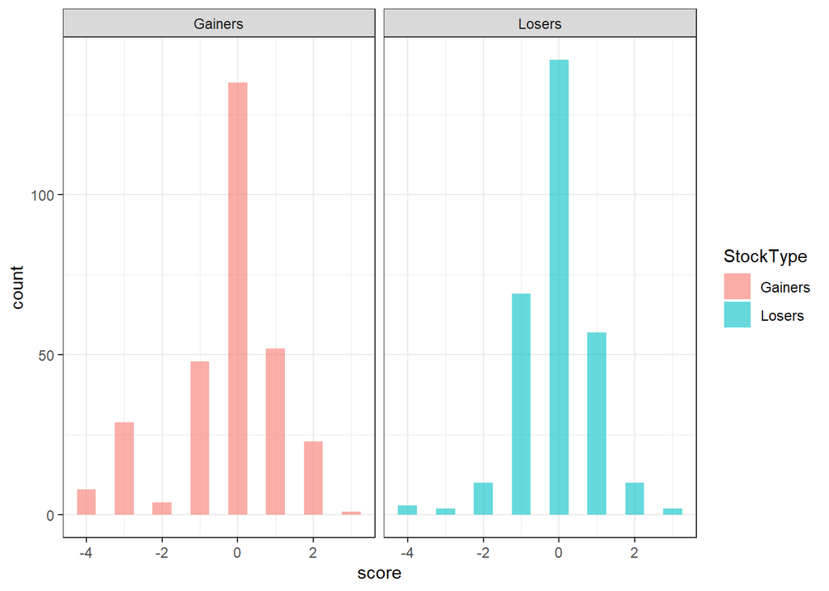

```r
# Compare sentiment for both "Gainers" and "Losers" tweet searches

# takes a minute or so
gainers_sent = lapply(twt.gainers$text,function(x){sentiment_bing(x)})
losers_sent = lapply(twt.losers$text,function(x){sentiment_bing(x)})


library(purrr)

stock_sentiment = bind_rows(
  tibble(
    StockType = 'Gainers',
    score = unlist(map(gainers_sent,'score')),
    type = unlist(map(gainers_sent,'type'))
  ),
  tibble(
    StockType = 'Losers',
    score = unlist(map(losers_sent,'score')),
    type = unlist(map(losers_sent,'type'))
  )
)

ggplot(stock_sentiment,aes(x=score, fill = StockType)) + geom_histogram(bins = 15, alpha = .6) +
  facet_grid(~StockType) + theme_bw()
```

```r
stock_sentiment %>% group_by(StockType) %>%
  summarise(
    Count = n(),
    Mean = mean(score),
    SD = sd(score),
    max = max(score),
    min = min(score)
  )
```

```
## # A tibble: 2 x 6
##   StockType Count    Mean    SD   max   min
##   <chr>     <int>   <dbl> <dbl> <dbl> <dbl>
## 1 Gainers     300 -0.247  1.40      3    -4
## 2 Losers      295 -0.0814 0.990     3    -4
```

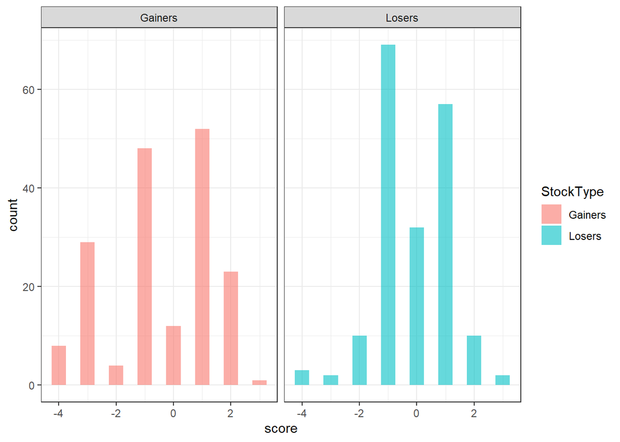

```r
## Now lets excluded the Type 1 tweets (tweets with no words in the bing list)

ggplot(stock_sentiment %>% filter(type != "Type 1"),aes(x=score, fill = StockType)) + geom_histogram(bins = 15, alpha = .6) +
  facet_grid(~StockType) + theme_bw()
```

```r
stock_sentiment %>% filter(type != "Type 1") %>% group_by(StockType) %>%
  summarise(
    Count = n(),
    Mean = mean(score),
    SD = sd(score),
    max = max(score),
    min = min(score)
  )
```

```
## # A tibble: 2 x 6
##   StockType Count   Mean    SD   max   min
##   <chr>     <int>  <dbl> <dbl> <dbl> <dbl>
## 1 Gainers     177 -0.418  1.81     3    -4
## 2 Losers      185 -0.130  1.25     3    -4
```

## Sentiments result summary

**Do the results make sense?**

The summary and the plot helps us understand the Type 2 tweets and the sentiments for both gainers and Losers stocks of the Day

```r
table(stock_sentiment %>% filter(type != "Type 1") %>% group_by(StockType))
```

```
## , , type = Type 2
##
##          score
## StockType -4 -3 -2 -1  0  1  2  3
##   Gainers  8 29  4 48 12 52 23  1
##   Losers   3  2 10 69 32 57 10  2
```